# Threshold Calibration Notebook

Independent Calibration of c_T, c_E, c_I for Early Termination Control

## 1. Introduction

This notebook implements independent calibration of the three threshold parameters: c_T, c_E, and c_I.

**Calibration Objective**: Achieve an Early Stop Rate (ESR) of approximately **60%-70%** in the corresponding “unfavorable scenario” where each module dominates early termination.

**Calibration Strategy**:

1. **c_T calibration**: Use “elevated toxicity” scenario where toxicity rule dominates early termination
2. **c_E calibration**: Use “low efficacy” scenario where efficacy rule dominates early termination
3. **c_I calibration**: Use “low immune response” scenario where immune rule dominates early termination

**Key Settings**:

- `enable_early_termination = TRUE` (required)
- Early termination triggers when admissible set becomes empty at any stage before final recommendation

## 2. Setup

```r
library(knitr)
library(ggplot2)
library(dplyr)
library(tidyr)

# Set working directory to project root
if (basename(getwd()) == "notebooks") {
  setwd("..")
}

# Source required functions
source("src/utils/helpers.R")
source("src/core/simulate_data.R")
source("src/core/model_utils.R")
source("src/decision/dose_decision.R")
source("src/core/main.R")

cat("Environment loaded successfully!\n")
```

```
Environment loaded successfully!
```

## 3. Base Configuration

Define the base trial configuration and threshold boundaries used for calibration.

```r
# Threshold boundaries (fixed)
phi_T <- 0.30  # Toxicity upper limit
phi_E <- 0.25  # Efficacy lower limit
phi_I <- 0.20  # Immune response lower limit

# Base trial configuration
create_base_config <- function(c_T = 0.5, c_E = 0.5, c_I = 0.5) {
  config <- list(
    dose_levels = c(1, 2, 3, 4, 5),
    n_stages = 5,
    cohort_size = 15,
    # Threshold boundaries
    phi_T = phi_T,
    phi_E = phi_E,
    phi_I = phi_I,
    # Probability thresholds (to be calibrated)
    c_T = c_T,
    c_E = c_E,
    c_I = c_I,
    # PoC parameters (not the focus here)
    c_poc = 0.9,
    delta_poc = 0.8,
    # Early termination settings (must be enabled)
    enable_early_termination = TRUE,
    log_early_termination = FALSE,
    verbose_logging = FALSE
  )

  # Utility table
  utility_table <- array(0, dim = c(2, 2, 2), dimnames = list(
    E = c(0, 1), T = c(0, 1), I = c(0, 1)
  ))
  utility_table[1, 1, 1] <- 0    # E=0, T=0, I=0
  utility_table[2, 1, 1] <- 80   # E=1, T=0, I=0
  utility_table[1, 2, 1] <- 0    # E=0, T=1, I=0
  utility_table[2, 2, 1] <- 30   # E=1, T=1, I=0
  utility_table[1, 1, 2] <- 10   # E=0, T=0, I=1
  utility_table[2, 1, 2] <- 100  # E=1, T=0, I=1
  utility_table[1, 2, 2] <- 0    # E=0, T=1, I=1
  utility_table[2, 2, 2] <- 40   # E=1, T=1, I=1
  config$utility_table <- utility_table

  return(config)
}

cat("Threshold Boundaries:\n")
```

```
Threshold Boundaries:
```

```r
cat("  phi_T (toxicity upper limit):", phi_T, "\n")
```

```
  phi_T (toxicity upper limit): 0.3
```

```r
cat("  phi_E (efficacy lower limit):", phi_E, "\n")
```

```
  phi_E (efficacy lower limit): 0.25
```

```r
cat("  phi_I (immune lower limit):", phi_I, "\n")
```

```
  phi_I (immune lower limit): 0.2
```

## 4. Scenario Definitions

### 4.1 Elevated Toxicity Scenario (c_T Calibration)

```r
# Elevated toxicity scenario: T slightly above threshold, E/I meet criteria
create_high_tox_scenario <- function() {
  # Toxicity slightly elevated (starting just above phi_T = 0.30, increasing)
  # Values are closer to threshold for moderate ESR
  p_YT_given_I <- matrix(c(
    # I=0
    0.32, 0.36, 0.40, 0.45, 0.50,
    # I=1 (slightly higher)
    0.35, 0.40, 0.45, 0.50, 0.55
  ), nrow = 5, ncol = 2)

  # Efficacy meets criteria (all > phi_E = 0.25, increasing)
  p_YE_given_I <- matrix(c(
    # I=0
    0.30, 0.35, 0.40, 0.45, 0.50,
    # I=1 (slightly higher)
    0.35, 0.40, 0.45, 0.50, 0.55
  ), nrow = 5, ncol = 2)

  # Immune response meets criteria (all > phi_I = 0.20, increasing)
  p_YI <- c(0.25, 0.30, 0.35, 0.40, 0.45)

  return(list(
    p_YI = p_YI,
    p_YT_given_I = p_YT_given_I,
    p_YE_given_I = p_YE_given_I,
    rho0 = 1.5,
    rho1 = 2.0,
    scenario_type = "high_toxicity",
    description = "Elevated Toxicity: T slightly above threshold, E/I meet criteria"
  ))
}

high_tox <- create_high_tox_scenario()
cat("Elevated Toxicity Scenario Parameters:\n")
```

```
Elevated Toxicity Scenario Parameters:
```

```r
cat("  p_YI (immune):", high_tox$p_YI, "\n")
```

```
  p_YI (immune): 0.25 0.3 0.35 0.4 0.45
```

```r
cat("  p_YT|I=0 (toxicity):", high_tox$p_YT_given_I[,1], "\n")
```

```
  p_YT|I=0 (toxicity): 0.32 0.36 0.4 0.45 0.5
```

```r
cat("  p_YT|I=1 (toxicity):", high_tox$p_YT_given_I[,2], "\n")
```

```
  p_YT|I=1 (toxicity): 0.35 0.4 0.45 0.5 0.55
```

```r
cat("  p_YE|I=0 (efficacy):", high_tox$p_YE_given_I[,1], "\n")
```

```
  p_YE|I=0 (efficacy): 0.3 0.35 0.4 0.45 0.5
```

```r
cat("  p_YE|I=1 (efficacy):", high_tox$p_YE_given_I[,2], "\n")
```

```
  p_YE|I=1 (efficacy): 0.35 0.4 0.45 0.5 0.55
```

### 4.2 Low Efficacy Scenario (c_E Calibration)

```r
# Low efficacy scenario: E slightly below threshold, T/I meet criteria
create_low_eff_scenario <- function() {
  # Toxicity safe (all < phi_T = 0.30, increasing)
  p_YT_given_I <- matrix(c(
    # I=0
    0.10, 0.14, 0.18, 0.22, 0.26,
    # I=1 (slightly higher)
    0.12, 0.16, 0.20, 0.24, 0.28
  ), nrow = 5, ncol = 2)

  # Efficacy slightly below threshold (approaching phi_E = 0.25, increasing)
  p_YE_given_I <- matrix(c(
    # I=0
    0.12, 0.15, 0.18, 0.20, 0.22,
    # I=1 (slightly higher)
    0.14, 0.17, 0.20, 0.22, 0.24
  ), nrow = 5, ncol = 2)

  # Immune response meets criteria (all > phi_I = 0.20, increasing)
  p_YI <- c(0.25, 0.30, 0.35, 0.40, 0.45)

  return(list(
    p_YI = p_YI,
    p_YT_given_I = p_YT_given_I,
    p_YE_given_I = p_YE_given_I,
    rho0 = 1.5,
    rho1 = 2.0,
    scenario_type = "low_efficacy",
    description = "Low Efficacy: E slightly below threshold, T/I meet criteria"
  ))
}

low_eff <- create_low_eff_scenario()
cat("Low Efficacy Scenario Parameters:\n")
```

```
Low Efficacy Scenario Parameters:
```

```r
cat("  p_YI (immune):", low_eff$p_YI, "\n")
```

```
  p_YI (immune): 0.25 0.3 0.35 0.4 0.45
```

```r
cat("  p_YT|I=0 (toxicity):", low_eff$p_YT_given_I[,1], "\n")
```

```
  p_YT|I=0 (toxicity): 0.1 0.14 0.18 0.22 0.26
```

```r
cat("  p_YT|I=1 (toxicity):", low_eff$p_YT_given_I[,2], "\n")
```

```
  p_YT|I=1 (toxicity): 0.12 0.16 0.2 0.24 0.28
```

```r
cat("  p_YE|I=0 (efficacy):", low_eff$p_YE_given_I[,1], "\n")
```

```
  p_YE|I=0 (efficacy): 0.12 0.15 0.18 0.2 0.22
```

```r
cat("  p_YE|I=1 (efficacy):", low_eff$p_YE_given_I[,2], "\n")
```

```
  p_YE|I=1 (efficacy): 0.14 0.17 0.2 0.22 0.24
```

### 4.3 Low Immune Response Scenario (c_I Calibration)

```r
# Low immune scenario: I slightly below threshold, T/E meet criteria
create_low_imm_scenario <- function() {
  # Toxicity safe (all < phi_T = 0.30, increasing)
  p_YT_given_I <- matrix(c(
    # I=0
    0.10, 0.14, 0.18, 0.22, 0.26,
    # I=1 (slightly higher)
    0.12, 0.16, 0.20, 0.24, 0.28
  ), nrow = 5, ncol = 2)

  # Efficacy meets criteria (all > phi_E = 0.25, increasing)
  p_YE_given_I <- matrix(c(
    # I=0
    0.30, 0.35, 0.40, 0.45, 0.50,
    # I=1 (slightly higher)
    0.35, 0.40, 0.45, 0.50, 0.55
  ), nrow = 5, ncol = 2)

  # Immune response slightly below threshold (approaching phi_I = 0.20, increasing)
  p_YI <- c(0.08, 0.11, 0.14, 0.16, 0.18)

  return(list(
    p_YI = p_YI,
    p_YT_given_I = p_YT_given_I,
    p_YE_given_I = p_YE_given_I,
    rho0 = 1.5,
    rho1 = 2.0,
    scenario_type = "low_immune",
    description = "Low Immune: I slightly below threshold, T/E meet criteria"
  ))
}

low_imm <- create_low_imm_scenario()
cat("Low Immune Response Scenario Parameters:\n")
```

```
Low Immune Response Scenario Parameters:
```

```r
cat("  p_YI (immune):", low_imm$p_YI, "\n")
```

```
  p_YI (immune): 0.08 0.11 0.14 0.16 0.18
```

```r
cat("  p_YT|I=0 (toxicity):", low_imm$p_YT_given_I[,1], "\n")
```

```
  p_YT|I=0 (toxicity): 0.1 0.14 0.18 0.22 0.26
```

```r
cat("  p_YT|I=1 (toxicity):", low_imm$p_YT_given_I[,2], "\n")
```

```
  p_YT|I=1 (toxicity): 0.12 0.16 0.2 0.24 0.28
```

```r
cat("  p_YE|I=0 (efficacy):", low_imm$p_YE_given_I[,1], "\n")
```

```
  p_YE|I=0 (efficacy): 0.3 0.35 0.4 0.45 0.5
```

```r
cat("  p_YE|I=1 (efficacy):", low_imm$p_YE_given_I[,2], "\n")
```

```
  p_YE|I=1 (efficacy): 0.35 0.4 0.45 0.5 0.55
```

## 5. Calibration Helper Functions

```r
#' Run a single simulation and extract metrics
#' @param config Trial configuration
#' @param scenario Scenario parameters
#' @param seed Random seed
run_single_simulation <- function(config, scenario, seed = NULL) {
  tryCatch({
    results <- run_trial_simulation(
      config,
      scenario$p_YI,
      scenario$p_YT_given_I,
      scenario$p_YE_given_I,
      scenario$rho0,
      scenario$rho1,
      seed = seed
    )

    return(list(
      terminated_early = results$terminated_early,
      termination_stage = ifelse(results$terminated_early, results$termination_stage, NA),
      final_od = ifelse(results$terminated_early, NA, results$final_od),
      total_participants = nrow(results$all_data),
      success = TRUE
    ))
  }, error = function(e) {
    return(list(
      terminated_early = TRUE,
      termination_stage = 1,
      final_od = NA,
      total_participants = 0,
      success = FALSE
    ))
  })
}

#' Run multiple simulations and calculate ESR
#' @param config Trial configuration
#' @param scenario Scenario parameters
#' @param n_sim Number of simulations
#' @param base_seed Base random seed
run_calibration_simulations <- function(config, scenario, n_sim = 500, base_seed = 12345) {
  results <- vector("list", n_sim)

  for (i in 1:n_sim) {
    results[[i]] <- run_single_simulation(config, scenario, seed = base_seed + i)
  }

  # Calculate ESR (Early Stop Rate)
  early_terminations <- sapply(results, function(x) x$terminated_early)
  esr <- mean(early_terminations)
  esr_se <- sqrt(esr * (1 - esr) / n_sim)

  # Termination stage distribution
  term_stages <- sapply(results, function(x) x$termination_stage)
  term_stages <- term_stages[!is.na(term_stages)]

  return(list(
    esr = esr,
    esr_se = esr_se,
    esr_ci_lower = max(0, esr - 1.96 * esr_se),
    esr_ci_upper = min(1, esr + 1.96 * esr_se),
    n_sim = n_sim,
    n_early_term = sum(early_terminations),
    termination_stage_dist = if(length(term_stages) > 0) table(term_stages) else NULL,
    results = results
  ))
}

#' Calibrate a single threshold parameter
#' @param param_name Parameter name ("c_T", "c_E", "c_I")
#' @param scenario Scenario parameters
#' @param candidates Candidate values vector
#' @param fixed_params Fixed parameter list
#' @param n_sim Number of simulations per candidate
#' @param target_esr_range Target ESR range
calibrate_threshold <- function(
  param_name,
  scenario,
  candidates,
  fixed_params = list(c_T = 0.5, c_E = 0.5, c_I = 0.5),
  n_sim = 500,
  target_esr_range = c(0.60, 0.70)
) {
  cat("\n", rep("=", 60), "\n", sep = "")
  cat("Calibrating:", param_name, "\n")
  cat("Scenario:", scenario$description, "\n")
  cat("Candidates:", paste(candidates, collapse = ", "), "\n")
  cat("Target ESR range:", target_esr_range[1], "-", target_esr_range[2], "\n")
  cat(rep("=", 60), "\n\n")

  results <- list()

  for (i in seq_along(candidates)) {
    candidate <- candidates[i]
    cat("Testing", param_name, "=", candidate, "... ")

    # Create config (update parameter being calibrated)
    params <- fixed_params
    params[[param_name]] <- candidate
    config <- create_base_config(c_T = params$c_T, c_E = params$c_E, c_I = params$c_I)

    # Run simulations
    sim_results <- run_calibration_simulations(
      config, scenario, n_sim = n_sim, base_seed = 10000 * i
    )

    results[[i]] <- list(
      param_value = candidate,
      esr = sim_results$esr,
      esr_se = sim_results$esr_se,
      esr_ci_lower = sim_results$esr_ci_lower,
      esr_ci_upper = sim_results$esr_ci_upper,
      n_early_term = sim_results$n_early_term,
      termination_stage_dist = sim_results$termination_stage_dist
    )

    cat("ESR =", round(sim_results$esr, 3),
        "(95% CI:", round(sim_results$esr_ci_lower, 3), "-",
        round(sim_results$esr_ci_upper, 3), ")\n")
  }

  # Find optimal value (ESR closest to target range center)
  target_center <- mean(target_esr_range)
  esr_values <- sapply(results, function(x) x$esr)

  # Find values within target range
  in_range <- which(esr_values >= target_esr_range[1] & esr_values <= target_esr_range[2])

  if (length(in_range) > 0) {
    # Select closest to center within range
    distances <- abs(esr_values[in_range] - target_center)
    optimal_idx <- in_range[which.min(distances)]
    optimal_value <- candidates[optimal_idx]
    optimal_esr <- esr_values[optimal_idx]
    status <- "Within target range"
  } else {
    # No value in range, select closest
    distances <- abs(esr_values - target_center)
    optimal_idx <- which.min(distances)
    optimal_value <- candidates[optimal_idx]
    optimal_esr <- esr_values[optimal_idx]
    status <- "Closest to target"
  }

  cat("\n", rep("-", 60), "\n", sep = "")
  cat("Calibration Result:\n")
  cat("  Recommended", param_name, "=", optimal_value, "\n")
  cat("  Corresponding ESR =", round(optimal_esr, 3), "\n")
  cat("  Status:", status, "\n")
  cat(rep("-", 60), "\n")

  return(list(
    param_name = param_name,
    candidates = candidates,
    results = results,
    optimal_value = optimal_value,
    optimal_esr = optimal_esr,
    target_range = target_esr_range,
    status = status
  ))
}

#' Plot calibration curve
#' @param calibration_result Return value from calibrate_threshold
plot_calibration_result <- function(calibration_result) {
  df <- data.frame(
    param_value = sapply(calibration_result$results, function(x) x$param_value),
    esr = sapply(calibration_result$results, function(x) x$esr),
    esr_ci_lower = sapply(calibration_result$results, function(x) x$esr_ci_lower),
    esr_ci_upper = sapply(calibration_result$results, function(x) x$esr_ci_upper)
  )

  p <- ggplot(df, aes(x = param_value, y = esr)) +
    # Target range
    geom_rect(aes(xmin = -Inf, xmax = Inf,
                  ymin = calibration_result$target_range[1],
                  ymax = calibration_result$target_range[2]),
              fill = "lightgreen", alpha = 0.3) +
    # Confidence interval
    geom_ribbon(aes(ymin = esr_ci_lower, ymax = esr_ci_upper),
                fill = "#2E86AB", alpha = 0.2) +
    # ESR curve
    geom_line(color = "#2E86AB", size = 1.2) +
    geom_point(color = "#2E86AB", size = 3) +
    # Optimal value
    geom_vline(xintercept = calibration_result$optimal_value,
               linetype = "dashed", color = "red", size = 1) +
    # Target range lines
    geom_hline(yintercept = calibration_result$target_range,
               linetype = "dotted", color = "darkgreen", size = 0.8) +
    # Labels
    labs(
      title = paste0(calibration_result$param_name, " Calibration Curve"),
      subtitle = paste0("Optimal: ", calibration_result$param_name, " = ",
                        calibration_result$optimal_value,
                        " (ESR = ", round(calibration_result$optimal_esr, 3), ")"),
      x = calibration_result$param_name,
      y = "Early Stop Rate (ESR)",
      caption = paste0("Target range: ",
                       calibration_result$target_range[1], "-",
                       calibration_result$target_range[2],
                       " (green area)")
    ) +
    scale_y_continuous(labels = scales::percent_format(), limits = c(0, 1)) +
    theme_bw(base_size = 14) +
    theme(
      plot.title = element_text(hjust = 0.5, face = "bold"),
      plot.subtitle = element_text(hjust = 0.5)
    )

  return(p)
}
```

## 6. c_T Calibration (Toxicity Threshold)

### 6.1 Run Calibration

```r
# Calibrate c_T, keeping c_E and c_I fixed
c_T_candidates <- seq(0.2, 0.5, by = 0.05)

c_T_calibration <- calibrate_threshold(
  param_name = "c_T",
  scenario = high_tox,
  candidates = c_T_candidates,
  fixed_params = list(c_T = 0.5, c_E = 0.5, c_I = 0.5),
  n_sim = 500,
  target_esr_range = c(0.60, 0.70)
)
```

```
============================================================
Calibrating: c_T
Scenario: Elevated Toxicity: T slightly above threshold, E/I meet criteria
Candidates: 0.2, 0.25, 0.3, 0.35, 0.4, 0.45, 0.5
Target ESR range: 0.6 - 0.7
= = = = = = = = = = = = = = = = = = = = = = = = = = = = = = = = = = = = = = = = = = = = = = = = = = = = = = = = = = = =

Testing c_T = 0.2 ... ESR = 0.84 (95% CI: 0.808 - 0.872 )
Testing c_T = 0.25 ... ESR = 0.852 (95% CI: 0.821 - 0.883 )
Testing c_T = 0.3 ... ESR = 0.89 (95% CI: 0.863 - 0.917 )
Testing c_T = 0.35 ... ESR = 0.948 (95% CI: 0.929 - 0.967 )
Testing c_T = 0.4 ... ESR = 0.942 (95% CI: 0.922 - 0.962 )
Testing c_T = 0.45 ... ESR = 0.952 (95% CI: 0.933 - 0.971 )
Testing c_T = 0.5 ... ESR = 0.98 (95% CI: 0.968 - 0.992 )

------------------------------------------------------------
Calibration Result:
  Recommended c_T = 0.2
  Corresponding ESR = 0.84
  Status: Closest to target
- - - - - - - - - - - - - - - - - - - - - - - - - - - - - - - - - - - - - - - - - - - - - - - - - - - - - - - - - - - -
```

### 6.2 Calibration Curve

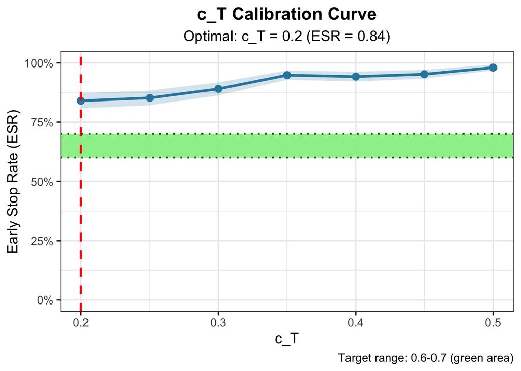

```r
plot_calibration_result(c_T_calibration)
```

### 6.3 Detailed Results

```r
c_T_df <- data.frame(
  c_T = sapply(c_T_calibration$results, function(x) x$param_value),
  ESR = sapply(c_T_calibration$results, function(x) round(x$esr, 3)),
  `95% CI` = sapply(c_T_calibration$results, function(x)
    paste0("[", round(x$esr_ci_lower, 3), ", ", round(x$esr_ci_upper, 3), "]")),
  `Early Terms` = sapply(c_T_calibration$results, function(x) x$n_early_term),
  Status = sapply(c_T_calibration$results, function(x) {
    if (x$esr >= 0.60 && x$esr <= 0.70) "Within target" else ""
  }),
  check.names = FALSE
)
c_T_df$Status[c_T_df$c_T == c_T_calibration$optimal_value] <- "RECOMMENDED"
kable(c_T_df, caption = "c_T Calibration Results")
```

c_T Calibration Results

| c_T | ESR | 95% CI | Early Terms | Status |
| --- | --- | --- | --- | --- |
| 0.20 | 0.840 | [0.808, 0.872] | 420 | RECOMMENDED |
| 0.25 | 0.852 | [0.821, 0.883] | 426 |  |
| 0.30 | 0.890 | [0.863, 0.917] | 445 |  |
| 0.35 | 0.948 | [0.929, 0.967] | 474 |  |
| 0.40 | 0.942 | [0.922, 0.962] | 471 |  |
| 0.45 | 0.952 | [0.933, 0.971] | 476 |  |
| 0.50 | 0.980 | [0.968, 0.992] | 490 |  |

## 7. c_E Calibration (Efficacy Threshold)

### 7.1 Run Calibration

```r
# Calibrate c_E, using recommended c_T, keeping c_I fixed
c_E_candidates <- seq(0.2, 0.5, by = 0.05)

c_E_calibration <- calibrate_threshold(
  param_name = "c_E",
  scenario = low_eff,
  candidates = c_E_candidates,
  fixed_params = list(c_T = c_T_calibration$optimal_value, c_E = 0.5, c_I = 0.5),
  n_sim = 500,
  target_esr_range = c(0.60, 0.70)
)
```

```
============================================================
Calibrating: c_E
Scenario: Low Efficacy: E slightly below threshold, T/I meet criteria
Candidates: 0.2, 0.25, 0.3, 0.35, 0.4, 0.45, 0.5
Target ESR range: 0.6 - 0.7
= = = = = = = = = = = = = = = = = = = = = = = = = = = = = = = = = = = = = = = = = = = = = = = = = = = = = = = = = = = =

Testing c_E = 0.2 ... ESR = 0.354 (95% CI: 0.312 - 0.396 )
Testing c_E = 0.25 ... ESR = 0.348 (95% CI: 0.306 - 0.39 )
Testing c_E = 0.3 ... ESR = 0.426 (95% CI: 0.383 - 0.469 )
Testing c_E = 0.35 ... ESR = 0.54 (95% CI: 0.496 - 0.584 )
Testing c_E = 0.4 ... ESR = 0.528 (95% CI: 0.484 - 0.572 )
Testing c_E = 0.45 ... ESR = 0.554 (95% CI: 0.51 - 0.598 )
Testing c_E = 0.5 ... ESR = 0.608 (95% CI: 0.565 - 0.651 )

------------------------------------------------------------
Calibration Result:
  Recommended c_E = 0.5
  Corresponding ESR = 0.608
  Status: Within target range
- - - - - - - - - - - - - - - - - - - - - - - - - - - - - - - - - - - - - - - - - - - - - - - - - - - - - - - - - - - -
```

### 7.2 Calibration Curve

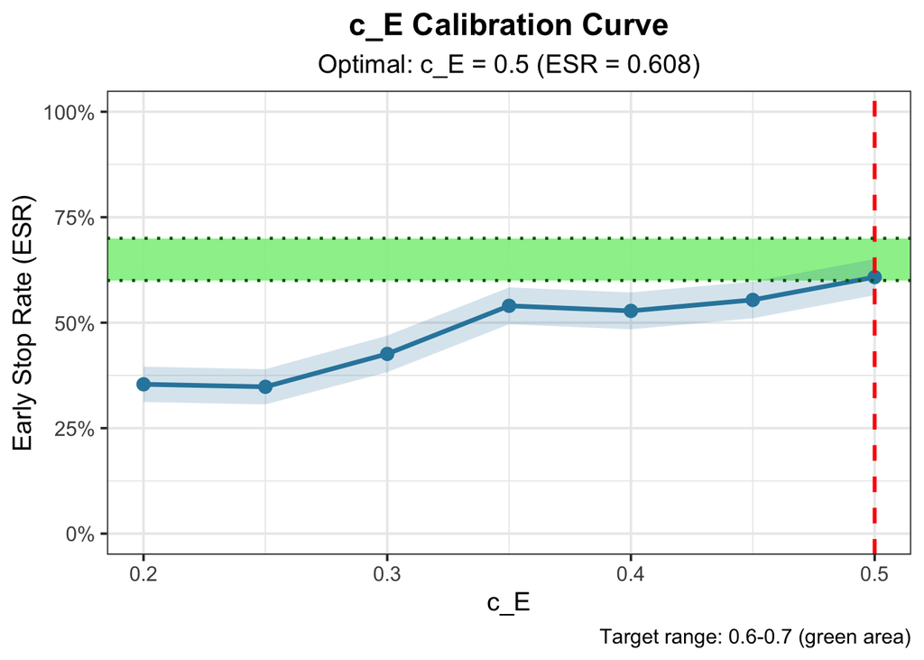

```r
plot_calibration_result(c_E_calibration)
```

### 7.3 Detailed Results

```r
c_E_df <- data.frame(
  c_E = sapply(c_E_calibration$results, function(x) x$param_value),
  ESR = sapply(c_E_calibration$results, function(x) round(x$esr, 3)),
  `95% CI` = sapply(c_E_calibration$results, function(x)
    paste0("[", round(x$esr_ci_lower, 3), ", ", round(x$esr_ci_upper, 3), "]")),
  `Early Terms` = sapply(c_E_calibration$results, function(x) x$n_early_term),
  Status = sapply(c_E_calibration$results, function(x) {
    if (x$esr >= 0.60 && x$esr <= 0.70) "Within target" else ""
  }),
  check.names = FALSE
)
c_E_df$Status[c_E_df$c_E == c_E_calibration$optimal_value] <- "RECOMMENDED"
kable(c_E_df, caption = "c_E Calibration Results")
```

c_E Calibration Results

| c_E | ESR | 95% CI | Early Terms | Status |
| --- | --- | --- | --- | --- |
| 0.20 | 0.354 | [0.312, 0.396] | 177 |  |
| 0.25 | 0.348 | [0.306, 0.39] | 174 |  |
| 0.30 | 0.426 | [0.383, 0.469] | 213 |  |
| 0.35 | 0.540 | [0.496, 0.584] | 270 |  |
| 0.40 | 0.528 | [0.484, 0.572] | 264 |  |
| 0.45 | 0.554 | [0.51, 0.598] | 277 |  |
| 0.50 | 0.608 | [0.565, 0.651] | 304 | RECOMMENDED |

## 8. c_I Calibration (Immune Response Threshold)

### 8.1 Run Calibration

```r
# Calibrate c_I, using recommended c_T and c_E
c_I_candidates <- seq(0.2, 0.5, by = 0.05)

c_I_calibration <- calibrate_threshold(
  param_name = "c_I",
  scenario = low_imm,
  candidates = c_I_candidates,
  fixed_params = list(c_T = c_T_calibration$optimal_value,
                      c_E = c_E_calibration$optimal_value,
                      c_I = 0.5),
  n_sim = 500,
  target_esr_range = c(0.60, 0.70)
)
```

```
============================================================
Calibrating: c_I
Scenario: Low Immune: I slightly below threshold, T/E meet criteria
Candidates: 0.2, 0.25, 0.3, 0.35, 0.4, 0.45, 0.5
Target ESR range: 0.6 - 0.7
= = = = = = = = = = = = = = = = = = = = = = = = = = = = = = = = = = = = = = = = = = = = = = = = = = = = = = = = = = = =

Testing c_I = 0.2 ... ESR = 0.394 (95% CI: 0.351 - 0.437 )
Testing c_I = 0.25 ... ESR = 0.54 (95% CI: 0.496 - 0.584 )
Testing c_I = 0.3 ... ESR = 0.558 (95% CI: 0.514 - 0.602 )
Testing c_I = 0.35 ... ESR = 0.668 (95% CI: 0.627 - 0.709 )
Testing c_I = 0.4 ... ESR = 0.684 (95% CI: 0.643 - 0.725 )
Testing c_I = 0.45 ... ESR = 0.742 (95% CI: 0.704 - 0.78 )
Testing c_I = 0.5 ... ESR = 0.77 (95% CI: 0.733 - 0.807 )

------------------------------------------------------------
Calibration Result:
  Recommended c_I = 0.35
  Corresponding ESR = 0.668
  Status: Within target range
- - - - - - - - - - - - - - - - - - - - - - - - - - - - - - - - - - - - - - - - - - - - - - - - - - - - - - - - - - - -
```

### 8.2 Calibration Curve

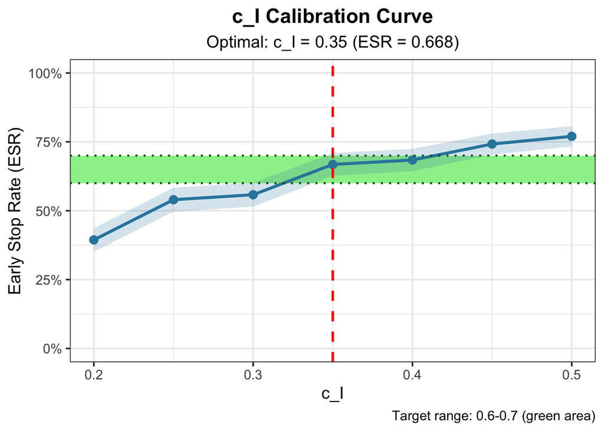

```r
plot_calibration_result(c_I_calibration)
```

### 8.3 Detailed Results

```r
c_I_df <- data.frame(
  c_I = sapply(c_I_calibration$results, function(x) x$param_value),
  ESR = sapply(c_I_calibration$results, function(x) round(x$esr, 3)),
  `95% CI` = sapply(c_I_calibration$results, function(x)
    paste0("[", round(x$esr_ci_lower, 3), ", ", round(x$esr_ci_upper, 3), "]")),
  `Early Terms` = sapply(c_I_calibration$results, function(x) x$n_early_term),
  Status = sapply(c_I_calibration$results, function(x) {
    if (x$esr >= 0.60 && x$esr <= 0.70) "Within target" else ""
  }),
  check.names = FALSE
)
c_I_df$Status[c_I_df$c_I == c_I_calibration$optimal_value] <- "RECOMMENDED"
kable(c_I_df, caption = "c_I Calibration Results")
```

c_I Calibration Results

| c_I | ESR | 95% CI | Early Terms | Status |
| --- | --- | --- | --- | --- |
| 0.20 | 0.394 | [0.351, 0.437] | 197 |  |
| 0.25 | 0.540 | [0.496, 0.584] | 270 |  |
| 0.30 | 0.558 | [0.514, 0.602] | 279 |  |
| 0.35 | 0.668 | [0.627, 0.709] | 334 | RECOMMENDED |
| 0.40 | 0.684 | [0.643, 0.725] | 342 | Within target |
| 0.45 | 0.742 | [0.704, 0.78] | 371 |  |
| 0.50 | 0.770 | [0.733, 0.807] | 385 |  |

## 9. Calibration Summary

```r
cat("\n")
```

```r
cat(rep("=", 70), "\n", sep = "")
cat("                    CALIBRATION SUMMARY\n")
```

```
                    CALIBRATION SUMMARY
```

```r
cat(rep("=", 70), "\n\n")
cat("Threshold Boundaries (Fixed):\n")
```

```
Threshold Boundaries (Fixed):
```

```r
cat("  phi_T (toxicity upper limit) = ", phi_T, "\n")
```

```
  phi_T (toxicity upper limit) =  0.3
```

```r
cat("  phi_E (efficacy lower limit) = ", phi_E, "\n")
```

```
  phi_E (efficacy lower limit) =  0.25
```

```r
cat("  phi_I (immune lower limit) = ", phi_I, "\n\n")
```

```
  phi_I (immune lower limit) =  0.2
```

```r
cat("Recommended Thresholds:\n")
```

```
Recommended Thresholds:
```

```r
cat("  ", rep("-", 55), "\n", sep = "")
cat("  Parameter |  Value  |  ESR     |  Target   |  Status\n")
```

```
  Parameter |  Value  |  ESR     |  Target   |  Status
```

```r
cat("  ", rep("-", 55), "\n", sep = "")
cat(sprintf("  c_T       |  %.2f   |  %.1f%%   |  60-70%%   |  %s\n",
            c_T_calibration$optimal_value,
            c_T_calibration$optimal_esr * 100,
            c_T_calibration$status))
```

```
  c_T       |  0.20   |  84.0%   |  60-70%   |  Closest to target
```

```r
cat(sprintf("  c_E       |  %.2f   |  %.1f%%   |  60-70%%   |  %s\n",
            c_E_calibration$optimal_value,
            c_E_calibration$optimal_esr * 100,
            c_E_calibration$status))
```

```
  c_E       |  0.50   |  60.8%   |  60-70%   |  Within target range
```

```r
cat(sprintf("  c_I       |  %.2f   |  %.1f%%   |  60-70%%   |  %s\n",
            c_I_calibration$optimal_value,
            c_I_calibration$optimal_esr * 100,
            c_I_calibration$status))
```

```
  c_I       |  0.35   |  66.8%   |  60-70%   |  Within target range
```

```r
cat("  ", rep("-", 55), "\n", sep = "")
cat("\nUsage:\n")
```

```
Usage:
```

```r
cat("Apply the following to your trial_config:\n\n")
```

```
Apply the following to your trial_config:
```

```r
cat("trial_config$c_T <-", c_T_calibration$optimal_value, "\n")
```

```
trial_config$c_T <- 0.2
```

```r
cat("trial_config$c_E <-", c_E_calibration$optimal_value, "\n")
```

```
trial_config$c_E <- 0.5
```

```r
cat("trial_config$c_I <-", c_I_calibration$optimal_value, "\n")
```

```
trial_config$c_I <- 0.35
```

```r
cat("\n")
```

```r
cat(rep("=", 70), "\n", sep = "")
```

## 10. Validation Tests

Validate the calibrated thresholds across all scenarios.

```r
cat("Validating calibrated thresholds...\n\n")
```

```
Validating calibrated thresholds...
```

```r
# Create config with all calibrated thresholds
calibrated_config <- create_base_config(
  c_T = c_T_calibration$optimal_value,
  c_E = c_E_calibration$optimal_value,
  c_I = c_I_calibration$optimal_value
)

# Validate in all three scenarios
scenarios <- list(
  high_toxicity = high_tox,
  low_efficacy = low_eff,
  low_immune = low_imm
)

validation_results <- list()
for (name in names(scenarios)) {
  cat("Validating scenario:", name, "... ")
  sim_res <- run_calibration_simulations(calibrated_config, scenarios[[name]], n_sim = 500)
  validation_results[[name]] <- sim_res
  cat("ESR =", round(sim_res$esr, 3), "\n")
}
```

```
Validating scenario: high_toxicity ... ESR = 0.786
Validating scenario: low_efficacy ... ESR = 0.438
Validating scenario: low_immune ... ESR = 0.654
```

```r
cat("\nValidation Summary:\n")
```

```
Validation Summary:
```

```r
cat("  Scenario         |  ESR      |  Expected\n")
```

```
  Scenario         |  ESR      |  Expected
```

```r
cat("  ", rep("-", 45), "\n", sep = "")
cat(sprintf("  High Toxicity    |  %.1f%%    |  ~60-70%% (c_T dominant)\n",
            validation_results$high_toxicity$esr * 100))
```

```
  High Toxicity    |  78.6%    |  ~60-70% (c_T dominant)
```

```r
cat(sprintf("  Low Efficacy     |  %.1f%%    |  ~60-70%% (c_E dominant)\n",
            validation_results$low_efficacy$esr * 100))
```

```
  Low Efficacy     |  43.8%    |  ~60-70% (c_E dominant)
```

```r
cat(sprintf("  Low Immune       |  %.1f%%    |  ~60-70%% (c_I dominant)\n",
            validation_results$low_immune$esr * 100))
```

```
  Low Immune       |  65.4%    |  ~60-70% (c_I dominant)
```

## 11. Combined Visualization

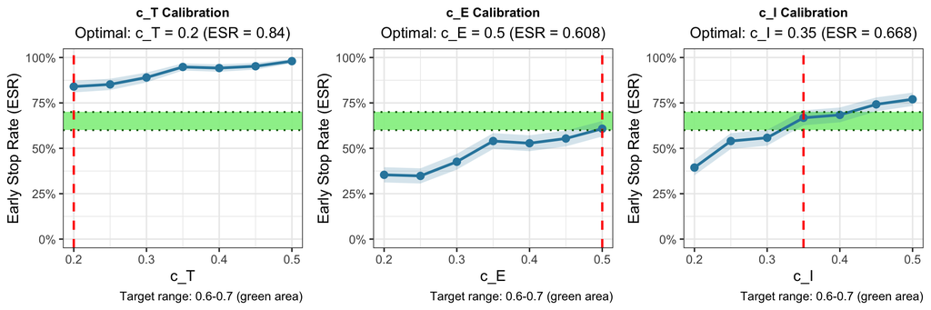

```r
library(gridExtra)
p1 <- plot_calibration_result(c_T_calibration) +
  ggtitle("c_T Calibration") +
  theme(plot.title = element_text(size = 12))

p2 <- plot_calibration_result(c_E_calibration) +
  ggtitle("c_E Calibration") +
  theme(plot.title = element_text(size = 12))

p3 <- plot_calibration_result(c_I_calibration) +
  ggtitle("c_I Calibration") +
  theme(plot.title = element_text(size = 12))

grid.arrange(p1, p2, p3, ncol = 3)
```

## 12. Save Results

```r
# Save calibration results to file
calibration_summary <- list(
  timestamp = Sys.time(),
  threshold_boundaries = list(phi_T = phi_T, phi_E = phi_E, phi_I = phi_I),
  recommended_thresholds = list(
    c_T = c_T_calibration$optimal_value,
    c_E = c_E_calibration$optimal_value,
    c_I = c_I_calibration$optimal_value
  ),
  esr_achieved = list(
    c_T = c_T_calibration$optimal_esr,
    c_E = c_E_calibration$optimal_esr,
    c_I = c_I_calibration$optimal_esr
  ),
  target_range = c(0.60, 0.70),
  n_sim_per_candidate = 500,
  calibration_details = list(
    c_T = c_T_calibration,
    c_E = c_E_calibration,
    c_I = c_I_calibration
  ),
  validation_results = validation_results
)

# Create results directory
if (!dir.exists("results/threshold_calibration")) {
  dir.create("results/threshold_calibration", recursive = TRUE)
}

# Save RDS
saveRDS(calibration_summary, "results/threshold_calibration/calibration_summary.rds")
cat("Calibration results saved to: results/threshold_calibration/calibration_summary.rds\n")
```

```
Calibration results saved to: results/threshold_calibration/calibration_summary.rds
```

```r
# Save text report
report_file <- "results/threshold_calibration/calibration_report.txt"
sink(report_file)
cat("Threshold Calibration Report\n")
cat("Generated:", format(calibration_summary$timestamp, "%Y-%m-%d %H:%M:%S"), "\n\n")
cat("Threshold Boundaries:\n")
cat("  phi_T =", phi_T, "\n")
cat("  phi_E =", phi_E, "\n")
cat("  phi_I =", phi_I, "\n\n")
cat("Recommended Thresholds:\n")
cat("  c_T =", c_T_calibration$optimal_value, "(ESR:", round(c_T_calibration$optimal_esr, 3), ")\n")
cat("  c_E =", c_E_calibration$optimal_value, "(ESR:", round(c_E_calibration$optimal_esr, 3), ")\n")
cat("  c_I =", c_I_calibration$optimal_value, "(ESR:", round(c_I_calibration$optimal_esr, 3), ")\n")
sink()
cat("Text report saved to:", report_file, "\n")
```

```
Text report saved to: results/threshold_calibration/calibration_report.txt
```

## Appendix: Technical Notes

### A.1 Calibration Methodology

This notebook uses the following calibration approach:

1. **Independent Calibration**: Adjust one parameter at a time, keeping others fixed
2. **Sequential Dependency**: c_T → c_E → c_I, subsequent calibrations use prior optimal values
3. **Target-Driven**: Select optimal value based on ESR = 60-70% target
4. **Monte Carlo**: Run 500 simulations per candidate, calculate 95% CI

### A.2 Scenario Design Principles

| Scenario | Purpose | T (increasing) | E (increasing) | I (increasing) |
| --- | --- | --- | --- | --- |
| High Toxicity | c_T calibration | Elevated [0.32→0.50] | Meets [0.30→0.50] | Meets [0.25→0.45] |
| Low Efficacy | c_E calibration | Safe [0.10→0.26] | Low [0.12→0.22] | Meets [0.25→0.45] |
| Low Immune | c_I calibration | Safe [0.10→0.26] | Meets [0.30→0.50] | Low [0.08→0.18] |

### A.3 How to Use Calibration Results

```r
# Load calibration results
calibration <- readRDS("results/threshold_calibration/calibration_summary.rds")

# Apply to configuration
trial_config$c_T <- calibration$recommended_thresholds$c_T
trial_config$c_E <- calibration$recommended_thresholds$c_E
trial_config$c_I <- calibration$recommended_thresholds$c_I
```